# A First Glance at Neural Networks for Medical Computer Vision

Matthew Emery

April 16, 2019

## Installation Guide

1. Install R 3.5: https://cran.r-project.org/
2. Install RStudio Desktop (Free): https://www.rstudio.com/products/rstudio/download/#download
3. Install Miniconda: https://docs.conda.io/en/latest/miniconda.html
4. Download and extract the code to this talk: https://github.com/lstmemery/r-keras-medical-imaging/archive/master.zip
5. Click on the .Rproj file
6. `packrat::restore()`
7. `keras::install_keras()`

## Who Am I?

- Alumni of the UBC Master of Data Science Program
- Previously: Software Developer at STEMCELL Technologies
- Senior data scientist at Imbellus Inc.

[figure not shown]

## Acknowledgements

- There is a bibliography in the repo
- This presentation is an adaptation of [Hello World Deep Learning in Medical Imaging](https://link.springer.com/article/10.1007/s10278-018-0079-6)
- [Fast.ai](https://www.fast.ai/) provides a great practitioner’s course on deep learning

## What is Machine Learning?

- Most of the time, programmers have input data and they apply a **known function** to get an unknown output.
- Machine learning is when you have input data and known outputs learn an **unknown function**.
- Examples: Linear Regression, Random Forest, Neural Networks

## Why Should I Care About Neural Nets?

1. Training is more **end-to-end** (i.e. they can learn features about data).
2. They perform well on problems that are appealing.
3. Tech companies open-source neural network architectures and frameworks.

## What are Neural Nets? (Please, No Math)

- They are large arrays of numbers that get multiplied by one another
- In between those multiplications, we apply a special function called an **activation function**
- Adjust these numbers using the **chain rule**

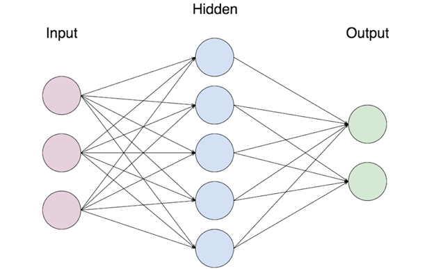

## What are Convolutional Neural Networks (CNNs)?

- CNNs are neural nets that work well for images
- Basic features of an image (edges etc.) are useful to know about anywhere in the image
- This allows the network to **share weights** between different areas of an image

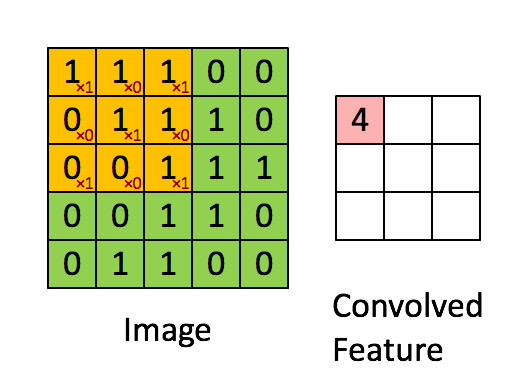

## First Layer Activations

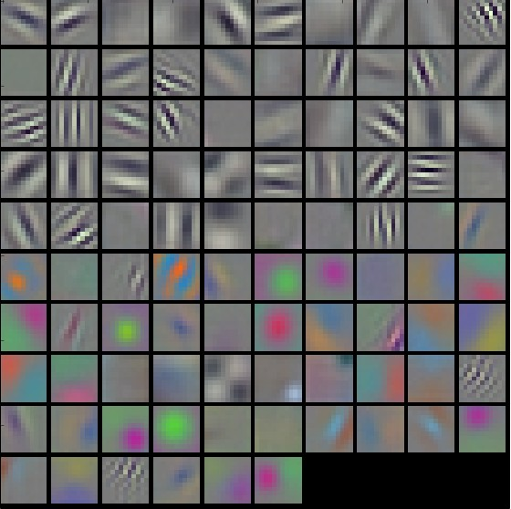

## How do you build neural networks?

- There are many frameworks in many languages
- The most popular language is **Python**
- We are using the high-level framework called **Keras** and **R**

[figure not shown]

## A Few Terms

- **Loss Function:** The function that the neural network is trying to minimize
- **Batch Size:** The number of images we feed into the neural net at a time
- **Epochs:** The number of times the neural network sees the whole training set

```r
# Constants
img_height <- 299L
img_width <- 299L
train_samples <- 65L
validation_samples <- 10L
epochs <- 3L
batch_size <- 5L
```

## The Dataset

- This is a “toy” dataset.
- Can we train a model to tell the difference between an abdominal and chest radiograph?

```r
# Finding Training
root <- find_rstudio_root_file()
train_data_directory <- path(root, "data", "TRAIN")
validation_data_directory <- path(root, "data", "VAL")
```

## Abdomen

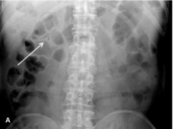

## Chest

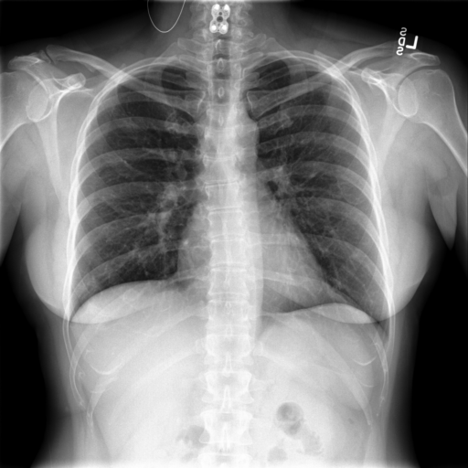

## Overfitting

- Separate your files into three groups, **training**, **validation** and **testing**.
- Think of them as textbook exercises, midterms and the final
- If you cram on the only a few questions, you will have only memorized the answers without learning.
- In machine learning, we call this **overfitting**.

## Model Validation

- The **validation set** is used at the end of each epoch to **guage overfitting.**.
- The neural net isn’t allowed to learn from the validation set directly.
- The test set is only used after the model is completely trained.
- The test set is used to **compare between models**.

## Preparing images

- Notice that these images are different sizes.
- Also the first image is slightly off-center.
- We want the network to be robust, so we will randomly change each image slightly.
- This is called **data augmentation**.

```r
#Play around with this!
train_data_generator <- image_data_generator(
  rescale = 1/255,
  shear_range = 0.2,
  zoom_range = 0.2,
  rotation_range = 20,
  width_shift_range = 0.2,
  height_shift_range = 0.2,
  horizontal_flip = TRUE
)

validation_data_generator <- image_data_generator(
  rescale = 1/255
)
```

## Generators

- **Binary classification** means there are only two classes.

```r
train_generator <- train_data_generator$flow_from_directory(
  train_data_directory,
  target_size = c(img_height, img_width),
  batch_size = batch_size,
  class_mode = "binary"
)

validation_generator <- validation_data_generator$flow_from_directory(
  validation_data_directory,
  target_size = c(img_height, img_width),
  batch_size = batch_size,
  class_mode = "binary"
)
```

## Transfer Learning

- Google has a designed an architecture to identify images called Inception-v3.
- These architectures are tested on ImageNet, a global competition to classify 1.4 million images into 1000 categories.

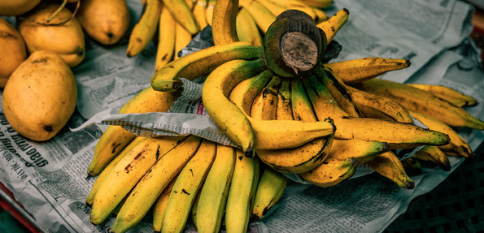

## Base Model

- **Inception-v3** is a state-of-the-art model.

```r
base_model <- application_inception_v3(
  weights = "imagenet",
  include_top = FALSE, # Keep the classification layer?
  input_shape = c(img_width,
                  img_height,
                  3L) # Three color channels
)
```

## Adding Our Own Layers

- Pooling layers
- Dense layers
- Dropout layers

```r
model_top <- base_model$output %>%
  layer_global_average_pooling_2d(trainable = TRUE) %>%
  layer_dense(512L,
              activation = "relu", # max(0, x)
              trainable = TRUE) %>%
  layer_dropout(0.5, trainable = TRUE) %>%
  layer_dense(1L,
              trainable = TRUE,
              activation = "sigmoid")
```

## Transferring the Model

- ADAM is a type of **gradient descent** method.
- **Binary cross entropy** is a smooth loss function that works well when you have two classes.

```r
full_model <- keras_model(
  inputs = base_model$input,
  outputs = model_top) %>%
  keras::compile(
    optimizer = optimizer_adam(
      lr = 0.0001, # How much do we update weights?
      epsilon = 1e-08, # Prevents Divide by 0 errors
      beta_1 = 0.9,
      beta_2 = 0.999,
      decay = 0.0
    ),
    loss = "binary_crossentropy",
    metrics = c("accuracy")
  )
```

## Training the Model

```r
history <- fit_generator( # Fit model
  full_model,
  generator = train_generator,
  steps_per_epoch = as.integer(train_samples / batch_size),
  epochs = epochs,
  validation_data = validation_generator,
  validation_steps = as.integer(validation_samples / batch_size)
)
```

## Testing

- Let’s go see if the model works!

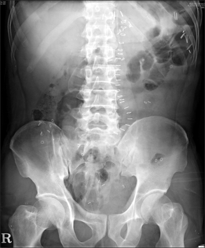

## Abdominal Prediction

```r
abdomen_test <- image_load("../data/TEST/abd2.png", target_size = c(299, 299)) %>%
  image_to_array() %>%
  array_reshape(dim = c(1, 299, 299, 3)) %>%
  imagenet_preprocess_input()

abdomen_prediction <- full_model %>%
  predict(abdomen_test)

if (abdomen_prediction < 0.5) {
  print("Chest X-ray")
} else {
  print("Abdomen X-ray")
}
```

```
## [1] "Chest X-ray"
```

## Chest Prediction

[figure not shown]

```r
chest_test <- image_load("../data/TEST/chest2.png", target_size = c(299, 299)) %>%
  image_to_array() %>%
  array_reshape(dim = c(1, 299, 299, 3)) %>%
  imagenet_preprocess_input()

chest_prediction <- full_model %>%
  predict(abdomen_test)

if (chest_prediction < 0.5) {
  print("Chest X-ray")
} else {
  print("Abdomen X-ray")
}
```

```
## [1] "Chest X-ray"
```

## What Happened?

- We overfit!
- We need more data.
- You could also try smaller learning rates or less epochs.

## Conclusion

- Anyone can make a neural network.
- Be careful about overfitting.
- The better your data, the better your model.